# Coordinated Reference Systems with sf 🌎

Workshop: I2DS Tools for Data Science - Exercises

Lisa Pramann & Caitlin Sarro

November 4th 2021

$~$

Hello everyone 👋,

we hope you have enjoyed our small presentation, refreshed your knowledge about Coordinate Reference Systems and got some insights on how geographic data they works in R and what potential data operations can be done with it.

Ready to play around with sf and do some simple operations and create a nice map in the end (hopefully) 😍?

In this little exercise we would like you to

- **get a better feeling for CRS and the `sf`- package**
- **understand how to access and read CRS data in R**
- **do simple data operations**
- **learn how to create cool and interactive maps based on geographic data**

# Theory

Refreshing you memory from the presentation…

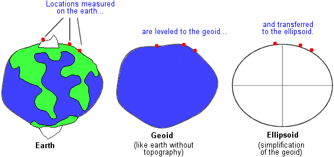

### Exercise (1)

**In your own words, why do we need a “Coordinate Reference System” (CRS)?**

```r
#
#
```

# Setup

The first step is to download the concerning packages and import the libraries for using `sf` and the *spatial data*.

```r
# install.packages("sf", "spData", "spDataLarge")

# The Essentials
library(sf)   # classes and functions for vector data
library(tidyverse)     # for tidy data and ggplot2

# Datasets
library(rgdal) # dataset of city centers (points)
library(spData) # load explanatory geographic data
library(spDataLarge) # load larger geographic data

#(Intermediary Mapping)
library(tmap) # to create nice and interactive maps
library(jsonlite) # Convert R objects to/from JSON
```

Be careful: There might be a little bug in installing `sf` and `spData`. If you’re running Mac or Linux, installing `sf` may not work directly. Please have a look [here](https://r-spatial.github.io/sf/) to download the relevant packages. Then use the `library()` command to load them.

# Exploring CRS in R

For these exercises we will work with the same dataset from the video. Our new object, `new_vector`, will be a polygon representing a world map. (For more info: ?spData::world).

First import the data and make it a readable to `sf`:

```r
vector_filepath <- system.file("shapes/world.gpkg", package = "spData")
new_vector <- read_sf(vector_filepath)
```

We’ve also loaded in a dataset of city centers from the `rgdal` package as the object `cities`.

## Retrieve the CRS from objects `new_vector` and `cities`

### Exercise (2)

** Using `st_crs` what can you tell about the data? Ex. the Datums and the retrieved Coordinate Reference System**

```r
#
#
```

### new_vector

```r
st_crs(new_vector)
```

```
## Coordinate Reference System:
##   User input: WGS 84
##   wkt:
## GEOGCRS["WGS 84",
##     DATUM["World Geodetic System 1984",
##         ELLIPSOID["WGS 84",6378137,298.257223563,
##             LENGTHUNIT["metre",1]]],
##     PRIMEM["Greenwich",0,
##         ANGLEUNIT["degree",0.0174532925199433]],
##     CS[ellipsoidal,2],
##         AXIS["geodetic latitude (Lat)",north,
##             ORDER[1],
##             ANGLEUNIT["degree",0.0174532925199433]],
##         AXIS["geodetic longitude (Lon)",east,
##             ORDER[2],
##             ANGLEUNIT["degree",0.0174532925199433]],
##     USAGE[
##         SCOPE["Horizontal component of 3D system."],
##         AREA["World."],
##         BBOX[-90,-180,90,180]],
##     ID["EPSG",4326]]
```

### cities

```r
st_crs(cities)
```

```
## Coordinate Reference System:
##   User input: EPSG:3138
##   wkt:
## PROJCRS["ETRS89 / ETRS-GK31FIN",
##     BASEGEOGCRS["ETRS89",
##         DATUM["European Terrestrial Reference System 1989",
##             ELLIPSOID["GRS 1980",6378137,298.257222101,
##                 LENGTHUNIT["metre",1]]],
##         PRIMEM["Greenwich",0,
##             ANGLEUNIT["degree",0.0174532925199433]],
##         ID["EPSG",4258]],
##     CONVERSION["Finland ETRS-GK31",
##         METHOD["Transverse Mercator",
##             ID["EPSG",9807]],
##         PARAMETER["Latitude of natural origin",0,
##             ANGLEUNIT["degree",0.0174532925199433],
##             ID["EPSG",8801]],
##         PARAMETER["Longitude of natural origin",31,
##             ANGLEUNIT["degree",0.0174532925199433],
##             ID["EPSG",8802]],
##         PARAMETER["Scale factor at natural origin",1,
##             SCALEUNIT["unity",1],
##             ID["EPSG",8805]],
##         PARAMETER["False easting",500000,
##             LENGTHUNIT["metre",1],
##             ID["EPSG",8806]],
##         PARAMETER["False northing",0,
##             LENGTHUNIT["metre",1],
##             ID["EPSG",8807]]],
##     CS[Cartesian,2],
##         AXIS["northing (N)",north,
##             ORDER[1],
##             LENGTHUNIT["metre",1]],
##         AXIS["easting (E)",east,
##             ORDER[2],
##             LENGTHUNIT["metre",1]],
##     USAGE[
##         SCOPE["Cadastre, engineering survey, topographic mapping (large scale)."],
##         AREA["Finland - east of 30°30'E."],
##         BBOX[62.08,30.5,64.27,31.59]],
##     ID["EPSG",3138]]
```

$~$

## Use `st_set_crs` to Add or Change CRS

```r
CRS_vector <- st_set_crs(world, "EPSG:4326")
```

To look up different Datums you can use a website for [Coordinate Systems Worldwide](https://epsg.io/)

### Exercise (3)

**How can we change the Datum for `cities`?**

```r
#
#
```

$~$

# Geographic Data Operations

## Geometric measurements

In the short presentation we have shown you the following examples of how to conduct two types of geometric measurements with the `sf`-package

*Example 1 from presentation:*

```r
Belgium <- world %>%
  filter(name_long == "Belgium")
st_area(Belgium)
```

```
## 30019548314 [m^2]
```

```r
units::set_units(st_area(Belgium), km^2)
```

```
## 30019.55 [km^2]
```

We can also do this calculation for a US-state:

```r
Florida <- us_states %>%
  filter(NAME == "Florida")
st_area(Florida)
```

```
## 1.51264e+11 [m^2]
```

### Exercise (4)

**`st_area()` is giving us the output in m^2. The output is however really difficult to read, and the US does operate with *miles*. How can we get an output in squared miles?**

```r
#
#
```

*Example 2 from presentation:*

Measuring the distance from a cycle hire point at the *Palace Gate* in London to the center of *Redbridge*.

```r
cycle_station_palace <- cycle_hire %>%
  filter(name == "Palace Gate")
redbridge <- lnd %>%
  filter(NAME == "Redbridge")
redbridge_centroid <- st_centroid(redbridge)
st_distance(cycle_station_palace, redbridge_centroid)
```

```
## Units: [m]
##         [,1]
## [1,] 20258.6
```

### Exercise (5)

**Have a look at the Code. What are the three steps one has to make, to measure distance between two geometric data points? Can we change the units of the output here, too? How?**

```r
#
#
```

- Tip: other interesting functions to explore geometric relations and distances with are `st_within()`,`st_is_within_distance()` or `st_touches()`. If you would like to find out what they do have a look [here](https://r-spatial.github.io/sf/reference/geos_binary_pred.html).

## Creating maps wit CRS data 🗺

In the presentation we have shown how to use `sf` in combination with `ggplot` or the `sf` and `plot()` function to create simple maps.

### Example with ggplot()

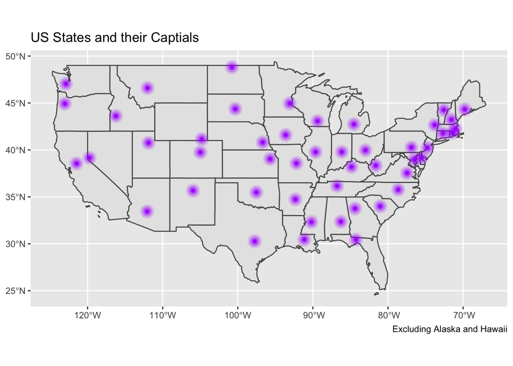

Example from the presentation using `ggplot()` in combination with `geom_sf()` from the `sf` package on data CRS data from the US retrieved from the `spData` package.

### Example with plot()

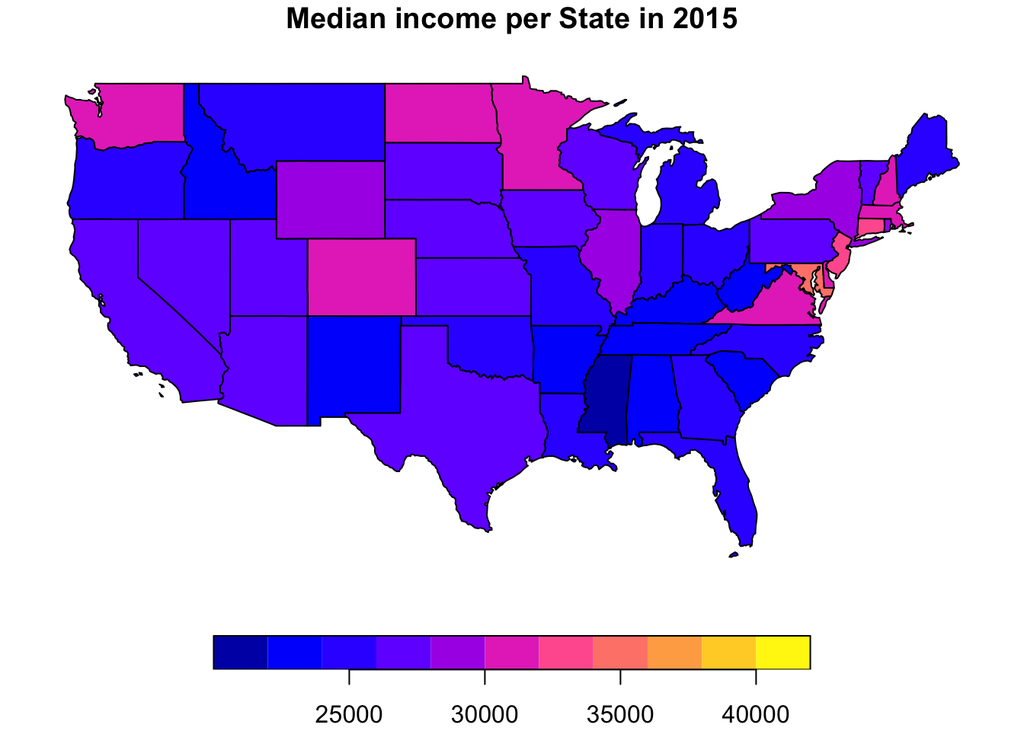

Example from the presentation using `plot()` on data CRS data from the US and attributed data on the median income per state, both retrieved from the `spData` package.

$~$

## Public Policy implications

### Exercise (6)

**During this workshop we’ve covered what CRS data is, the functions of the sf package, and how it can be used. Now brainstorm some applications; What are scenarios (how or when) where you can apply these tools in the future?**

```r
#
#
```

## Take-home exercise: Introducing tmap()

### Exercise (7)

**In the presentation we mentioned the `tmap` package which offers a bit more comprehensive tools, for example interactive mapping. Please do a quick research. Which function from the `tmap`-package can we use to set an interactive view of a map?**

```r
#
#
```

[interactive chart not shown]

$~$

# Sources

The workshop and these exercises are based on [*Geocompuataion with R Science*](https://geocompr.robinlovelace.net/spatial-class.html#crs-intro), section 2.4, [tmap: get started!](https://cran.r-project.org/web/packages/tmap/vignettes/tmap-getstarted.html#interactive-maps)